# Estimating Average Food Consumption Per Person At The Community Cafe At Urban Ministries of Durham

Tianyi Liu

10/07/2019

# Background

> For every threadbare tee and pair of stained pants, there is an equal number of belted slacks and button-down shirts. *Patrons are of every color and every age, each with a unique set of circumstances that brought them to UMD. It makes no difference why they’re here to the staff and volunteers who have put together enough food to feed 250*. No one will ask questions or make them justify their place in line. — Elizabeth Shestak, [A Daily Slice of Life at Urban Ministries of Durham](https://www.ourstate.com/a-daily-slice-of-life-at-urban-ministries-of-durham/)

The community cafe at Urban Ministries of Durham (UMD) has long been a place where people under different life circumstances enjoy a free meal with food donated by the local partners and prepared by hardworking staff and volunteers until they are settled for steady jobs or complete drug rehabilitation treatments. As the quote above states, the staff and volunteers put together food enough for feeding 250 each meal. Per the [same source](https://www.ourstate.com/a-daily-slice-of-life-at-urban-ministries-of-durham/), the cafe serves 2 meals on weekdays and 3 on weekends, producing a total of 4000 meals per week. That’s a surprisingly large amount of food to handle. Astoundingly, during the recent fiscal year of 2014-15, UMD kept the cafe running on a $30,000 annual food budget and served over a quarter of a million meals to needy people.

However, to keep the budgets low and fully utilize the donated food items from the local community, an estimate of how much food a person takes on average per meal might be useful for the cafe to serve the best portions for each meal. To achieve this, we use the data set from UMD and compute the estimate through building a simple linear regression model on the data available.

# Data Set

The data set used in this analysis was a record of resource distribution at UMD. It has 79838 entries, each corresponding to the bookkeepping of the distribution of certain resources at a certain check point on a certain day. The data set has 18 different columns, the first with the dates when the distributions were recorded and the rest items being distributed. The columns relevant to our analysis are those titled `Date`, `Food.Provided.for`, and `Food.Pounds`. The latter two stand for the number of people receiving meals and the weight of food in pounds served to those people on the date these numbers were recorded. **Hence, our model will estimate the weight of food a person takes in on average during a day**. Sometimes, multiple lines of entries can correspond to the same date, and multiple data are missing on each column. We will group the data for each date and clean up missing records before proceeding to the main analysis.

# Analysis

## Reading And Tidying Data

First, we read the data from the Urban Ministry of Durham and then chop it down to the three variables we selected: `Date`, `Food.Provided.for`, and `Food.Pounds`.

```r
dat <- as_tibble(read.csv(file = "/Users/gr8lawrence/Desktop/Bios_611/bios611-projects-fall-2019-gr8lawrence/project_1/data/UMD_Services_Provided_20190719.tsv", sep = "\t", header = TRUE))
dat_food <- dat %>%
  select(Date, Food.Provided.for, Food.Pounds)
# print the food data
head(dat_food)
```

```
## # A tibble: 6 x 3
##   Date       Food.Provided.for Food.Pounds
##   <fct>                  <int>       <int>
## 1 1/22/2009                  3          20
## 2 1/29/2009                  4          25
## 3 1/20/2009                  6          40
## 4 11/26/2002                 4          NA
## 5 12/2/2002                  3          NA
## 6 10/10/2002                NA          NA
```

Then we tidy the data by setting the dates to the correct formats and removing all rows that contain `NA`.

```r
# correct the date format and remove the rows with missing values
dat_food$Date <- as.Date(dat_food$Date, "%m/%d/%Y")
dat_food_tidied <- na.omit(dat_food)
# print the tidied data
head(dat_food_tidied)
```

```
## # A tibble: 6 x 3
##   Date       Food.Provided.for Food.Pounds
##   <date>                 <int>       <int>
## 1 2009-01-22                 3          20
## 2 2009-01-29                 4          25
## 3 2009-01-20                 6          40
## 4 2008-02-19                 0           0
## 5 1931-05-01                 1          15
## 6 2005-12-12                 1          10
```

A word on the quality of the data: a total of 30491 rows contain missing entries.

## Cleaning And Summarizing The Data

We summarize the distributions of daily food consumptions per person and the correlation between the food consumed and the number of people.

Before that, we check if there is any abnormal entries for the number of customers served (because this will serve as the denominator of the average food consumption).

```r
range(dat_food_tidied$Food.Provided.for)
```

```
## [1]    0 1151
```

We should remove the rows with 0. We also check if the dates are correct.

```r
range(dat_food_tidied$Date)
```

```
## [1] "1931-01-12" "2021-12-05"
```

For some reason the data also contains chronological mistakes. We remove the rows with dates later than “2019-09-10”, the date before the UMD staff presented their data.

```r
dat_food_tidied <- dat_food_tidied %>%
  filter(Food.Provided.for > 0) %>%
  filter(Date < as.Date("2019-09-10"))
```

Now we calculate the average food consumption per person per day

```r
avg_food <- dat_food_tidied %>%
  group_by(Date) %>%
  summarise(total_food_provided = sum(Food.Pounds),
            total_person_count = sum(Food.Provided.for),
            avg_food_consumed = sum(Food.Pounds)/sum(Food.Provided.for)) %>%
  arrange(desc(avg_food_consumed)) %>%
  na.omit() # remove the missing values after summarizing
# show the top six observations
head(avg_food)
```

```
## # A tibble: 6 x 4
##   Date       total_food_provided total_person_count avg_food_consumed
##   <date>                   <int>              <int>             <dbl>
## 1 2018-06-12              450507                 36           12514.
## 2 2018-04-06                2031                 18             113.
## 3 2018-01-26                5775                 52             111.
## 4 2018-03-06                2311                 42              55.0
## 5 2017-11-29                2370                 44              53.9
## 6 2018-03-14                2303                 46              50.1
```

Obviously, the first line printed above is an outlier. We go back and check:

```r
head(dat_food_tidied %>%
       filter(Date == as.Date("2018-06-12")) %>%
       arrange(desc(Food.Pounds)))
```

```
## # A tibble: 6 x 3
##   Date       Food.Provided.for Food.Pounds
##   <date>                 <int>       <int>
## 1 2018-06-12                 5      450121
## 2 2018-06-12                 4          38
## 3 2018-06-12                 4          38
## 4 2018-06-12                 3          28
## 5 2018-06-12                 3          28
## 6 2018-06-12                 3          28
```

The line with 450121 pounds of food distributed in one day was certainly abnormal, probably due to some typos. To minimally impact the data, we remove the row with the outlier and summarize the data again.

```r
food_pounds_outlier <- max(dat_food_tidied %>%
                             filter(Date == as.Date("2018-06-12")) %>%
                             select(Food.Pounds))

avg_food_2 <- dat_food_tidied %>%
  filter(Food.Pounds != food_pounds_outlier) %>%
  group_by(Date) %>%
  summarise(total_food_provided = sum(Food.Pounds),
            total_person_count = sum(Food.Provided.for),
            avg_food_consumed = sum(Food.Pounds)/sum(Food.Provided.for)) %>%
  arrange(desc(avg_food_consumed)) %>%
  na.omit()

# inspect the data
head(avg_food_2)
```

```
## # A tibble: 6 x 4
##   Date       total_food_provided total_person_count avg_food_consumed
##   <date>                   <int>              <int>             <dbl>
## 1 2018-04-06                2031                 18             113.
## 2 2018-01-26                5775                 52             111.
## 3 2018-03-06                2311                 42              55.0
## 4 2017-11-29                2370                 44              53.9
## 5 2018-03-14                2303                 46              50.1
## 6 2017-12-12                4723                104              45.4
```

Now we have removed the abnormal entries in the data. Next, we add the z-score of each day’s average food consumption per person and flag the values with an absoulte z-score greater than 2 for data filtering later. For a series of data $x$ the z-score for each member of the series $x_i$ is calculated by
$$z_i = \frac{x_i - \textrm{mean}(x)}{\textrm{sd}(x)}$$

```r
# flag the extreme average values
avg_food_2 <- avg_food_2 %>%
  mutate(avg_z = (avg_food_consumed - mean(avg_food_2$avg_food_consumed))/ sd(avg_food_2$avg_food_consumed),
         flag_avg = ifelse(abs(avg_z) > 2, "Extreme averages", "Normal averages")) %>%
  arrange(desc(avg_food_consumed))

# print the revised data set
head(avg_food_2)
```

```
## # A tibble: 6 x 6
##   Date       total_food_prov… total_person_co… avg_food_consum… avg_z
##   <date>                <int>            <int>            <dbl> <dbl>
## 1 2018-04-06             2031               18            113.  27.7
## 2 2018-01-26             5775               52            111.  27.2
## 3 2018-03-06             2311               42             55.0 12.2
## 4 2017-11-29             2370               44             53.9 11.9
## 5 2018-03-14             2303               46             50.1 10.9
## 6 2017-12-12             4723              104             45.4  9.65
## # … with 1 more variable: flag_avg <chr>
```

To inspect whether the data wholly make sense after we remove the aforementioned extreme outlier in the food in pounds distributed per day, we plot the relative distribution in 2D between food consumed in pounds and number of people provided with food each day with a line that shows the average of food consumption per day per person calculated from `avg_food_2` as a reference.

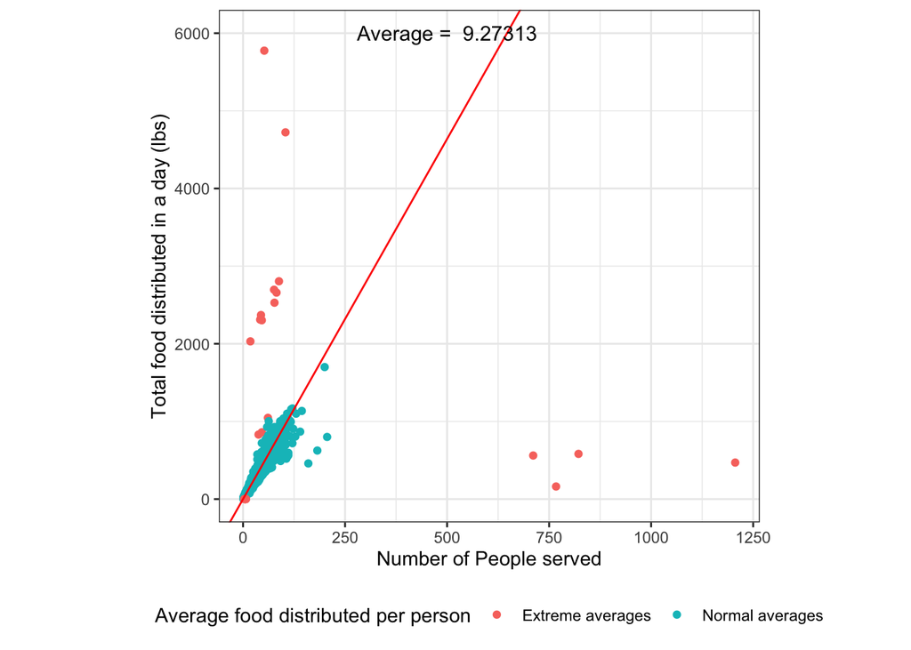

```r
# plot the correlation
ggplot(avg_food_2, aes(x = total_person_count , y = total_food_provided, col = flag_avg)) +
  coord_fixed(ratio = 1/5.25) +
  geom_point() +
  geom_abline(intercept = 0, slope = mean(avg_food_2$avg_food_consumed), col = "red") +
  labs(x = "Number of People served",
       y = "Total food distributed in a day (lbs)") +
  annotate("text", x = 500, y = 6000, size = 4, label = paste("Average = ", signif(mean(avg_food_2$avg_food_consumed)))) +
  theme_bw() +
  theme(legend.position = "bottom") +
  scale_color_discrete(name = "Average food distributed per person")
```

We certainly see points that lie far away from the diagonal. Any of the following reasons could have caused them:

- Mistakes during data entrances
- Somebody claimed a lot of food for other family members or friends at the shelter (over-allocation)
- Limited food for a lot of people (under-allocation)
- Bad handling food allocation by the cafe staff (both)

But for now we do not know anything special about them. Thus, to minimize the effect of outliers in fitting our models, we remove the records with extreme average values that are 2 standard deviations away from the mean ($|z_i| > 2$), which are the dots marked “Extreme averages” in the above plot.

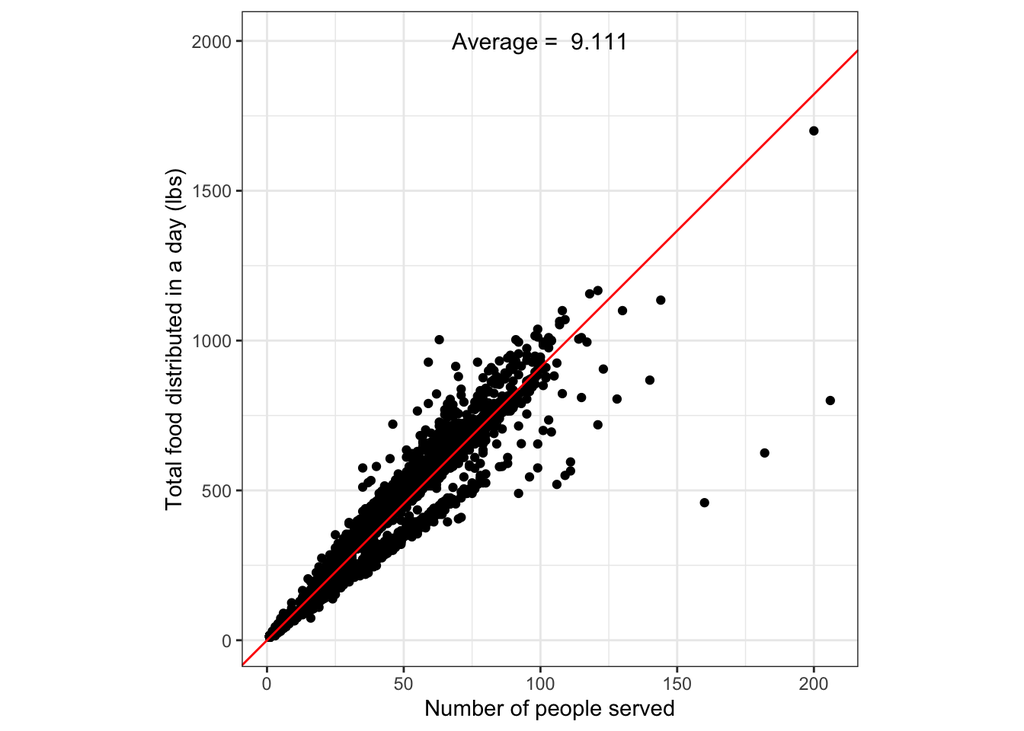

```r
avg_food_3 <- avg_food_2[-which(abs(avg_food_2$avg_z) > 2), ]

# plot the correlation again
ggplot(avg_food_3, aes(x = total_person_count , y = total_food_provided)) +
  coord_fixed(ratio = 1/9.12) +
  geom_point() +
  geom_abline(intercept = 0, slope = mean(avg_food_3$avg_food_consumed), col = "red") +
  labs(x = "Number of people served",
       y = "Total food distributed in a day (lbs)") +
  annotate("text", x = 100, y = 2000, size = 4, label = paste("Average = ", signif(mean(avg_food_3$avg_food_consumed)))) +
  theme_bw()
```

As some additional information, we plot the density of the per person food consumpution per day on average:

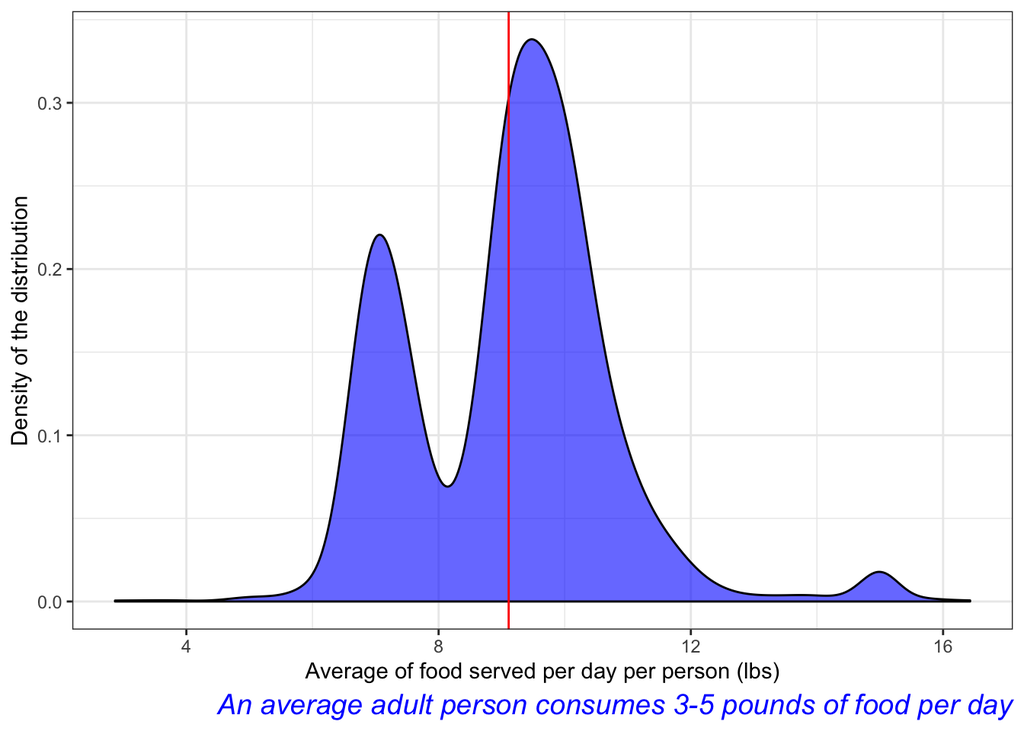

```r
# plot the distribution of average food consumption per person per day
ggplot(avg_food_3, aes(x = avg_food_consumed)) +
  geom_density(fill = "blue", alpha = 0.6) +
  geom_vline(xintercept = mean(avg_food_3$avg_food_consumed), col = "red") +
  labs(x = "Average of food served per day per person (lbs)",
       y = "Density of the distribution",
       caption = "An average adult person consumes 3-5 pounds of food per day") +
  theme_bw() +
  theme(plot.caption = element_text(color = "blue", face = "italic", size = 14))
```

The source for the statement in the footnote is [here](https://www.precisionnutrition.com/what-are-your-4-lbs). Some observations from this plot can be made here:

- Most people need around 9 pounds of food per day (*this contradicts the average reported by he external data! Probably the units in the records are family. But Viki from UMD said “people and families”. Need more clarifications!*)
- The data distribution is bimodal – has two peaks. This probably separates different genders, ages,etc. However, no more auxiliary variables can help us tell them apart from the data.

## The Main Analysis: Building The Model

Now, we fit the simple linear regression model to find the best estimate for the average food distributed in pounds per person per day and plot it. To achieve this, we need the following helper function, based on the original by [Susan Johnston](https://sejohnston.com/2012/08/09/a-quick-and-easy-function-to-plot-lm-results-in-r/):

```r
ggplotRegression <- function (fit) {
ggplot(fit$model, aes_string(x = names(fit$model)[2], y = names(fit$model)[1])) +
  geom_point() +
  stat_smooth(method = "lm", col = "red") +
  labs(caption = paste("adjusted r-square =", signif(summary(fit)$adj.r.squared, 4),
                       ", slope =", signif(fit$coef[[1]], 4),
                       ", p =", signif(summary(fit)$coef[1, 4], 4))) +
  theme_bw() +
  theme(plot.caption = element_text(color = "blue", face = "italic", size = 14))
}
```

Then we make the plot

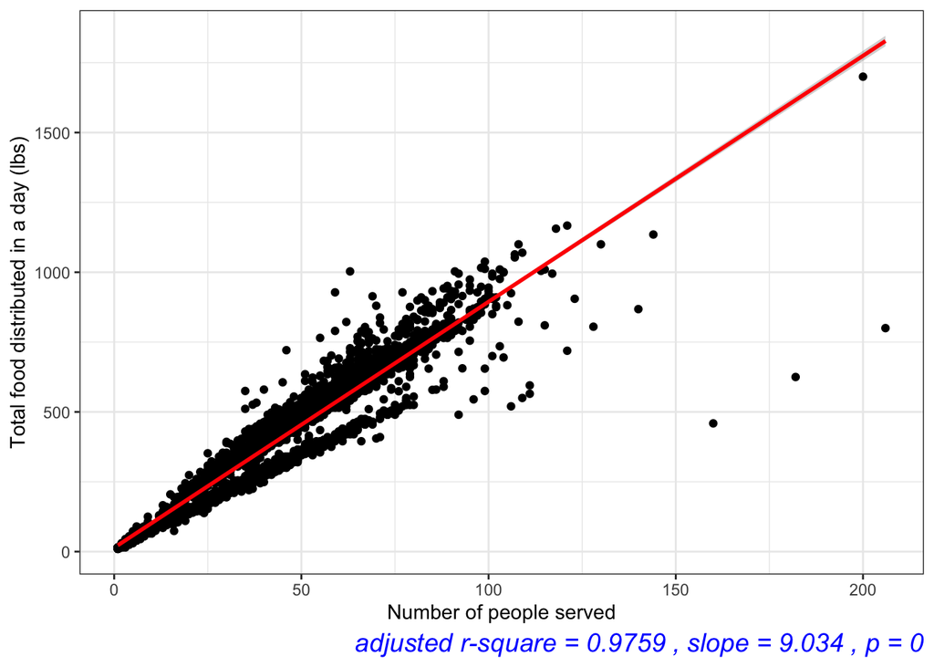

```r
# fitting a linear regression model without intercept
fit1 <- lm(total_food_provided ~ total_person_count - 1, data = avg_food_3)
p <- ggplotRegression(fit1) +
  labs(x = "Number of people served",
       y = "Total food distributed in a day (lbs)")
p
```

The plot shows that, on average, a person takes 9.035 pounds of food at the community cafe at UMD per day. The model fits the data well as seen by the adjusted r-square and p-value of nearly 0 (which was rounded to 0) for the slope test.

# Is This The Answer?

The model seems enticing because it fits the data well. However, does this really answer our question? If 9.035 pounds of food per person per day seems a little too much, then what could be the issue? Also, what is the reason behind the bimodality of our average food consumption?

Since there is no auxiliary variable and instant feedback, we cannot tell the exact reason. However (credits to one of the feedbacks I received), the data could be a mixture of food distributed in both the Cafe and the Pantry. *Therefore, the food could weigh pretty heavy because the weights of the containers could be added to the total weight. Moreover, a customer could take a month’s worth of food at one time, inflating the total amount of food distributed*. This might also explain those outliers we removed before doing the simple linear regression.

Therefore, maybe it is reasonable that we perform some clustering on the average food weight data in the original dataset (assuming that it did not mix the cafe and pantry data for each line) and see if there is more patterns within it. We use the k-mean clustering method with total number of clusters $k = 2$.

```r
# set randomization seed
set.seed(100)

# perform the k-mean clustering and attach the cluster number to the original data set
k_means <- dat_food_tidied %>%
    filter(Food.Pounds != food_pounds_outlier) %>%
    select(Food.Pounds, Food.Provided.for) %>%
    kmeans(2)

clustered_data <- dat_food_tidied %>%
  filter(Food.Pounds != food_pounds_outlier) %>%
  mutate(cluster = factor(k_means$cluster))
```

Then we plot the clustered data from different views:

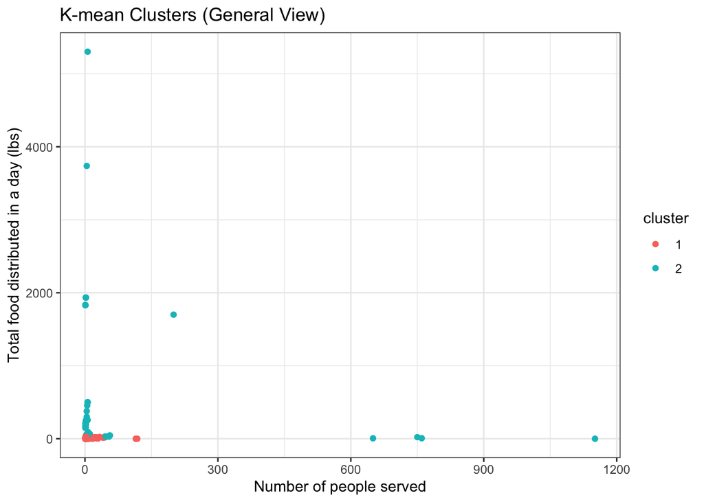

```r
ggplot(clustered_data, aes(x = Food.Provided.for, y = Food.Pounds, col = cluster)) +
  geom_point() +
  labs(title = "K-mean Clusters (General View)",
       x = "Number of people served",
       y = "Total food distributed in a day (lbs)") +
  theme_bw()
```

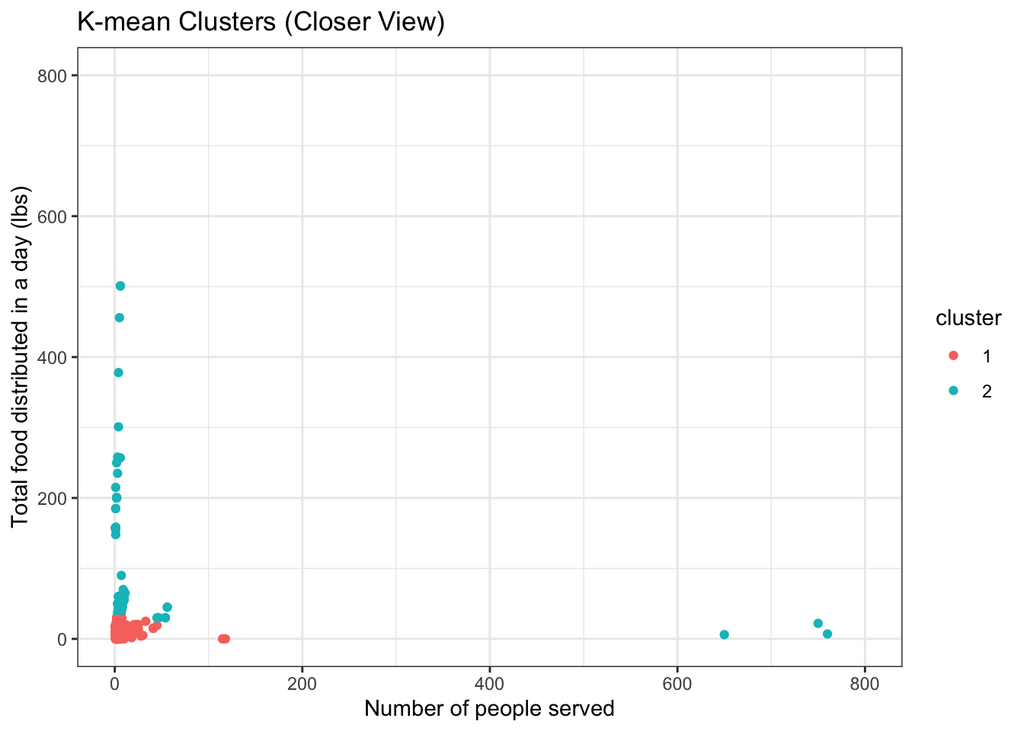

```r
ggplot(clustered_data, aes(x = Food.Provided.for, y = Food.Pounds, col = cluster)) +
  geom_point() +
  xlim(0, 800) +
  ylim(0, 800) +
  labs(title = "K-mean Clusters (Closer View)",
       x = "Number of people served",
       y = "Total food distributed in a day (lbs)") +
  theme_bw()
```

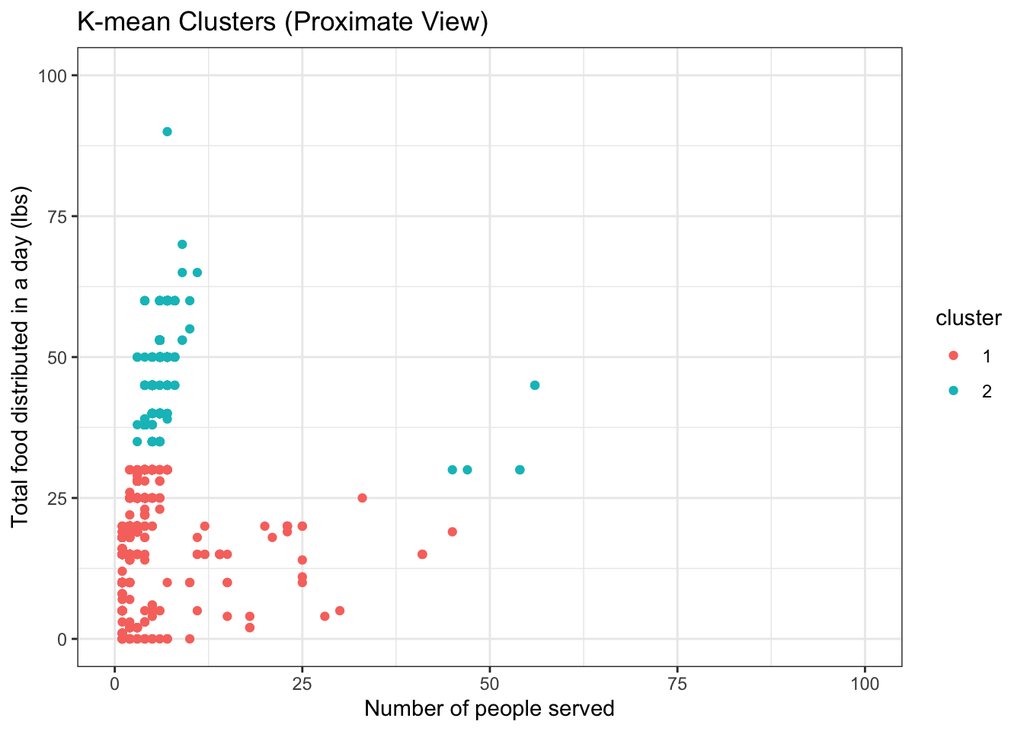

```r
ggplot(clustered_data, aes(x = Food.Provided.for, y = Food.Pounds, col = cluster)) +
  geom_point() +
  xlim(0, 100) +
  ylim(0, 100) +
  labs(title = "K-mean Clusters (Proximate View)",
       x = "Number of people served",
       y = "Total food distributed in a day (lbs)") +
  theme_bw()
```

Now let’s inspect the average food consumption per person per day in each cluster:

```r
clustered_data_summary <- clustered_data %>%
  mutate(avg_food_consumption = Food.Pounds/Food.Provided.for) %>%
  na.omit() %>%
  group_by(cluster) %>%
  summarise(cluster_mean_avg_food_consumption = mean(avg_food_consumption),
            n = sum(Food.Provided.for))

clustered_data_summary
```

```
## # A tibble: 2 x 3
##   cluster cluster_mean_avg_food_consumption     n
##   <fct>                               <dbl> <int>
## 1 1                                    11.3 79069
## 2 2                                    10.3 59955
```

This seems to filter out the extreme values in cluster 2. We take only the data from cluster 1 and does the same analysis again

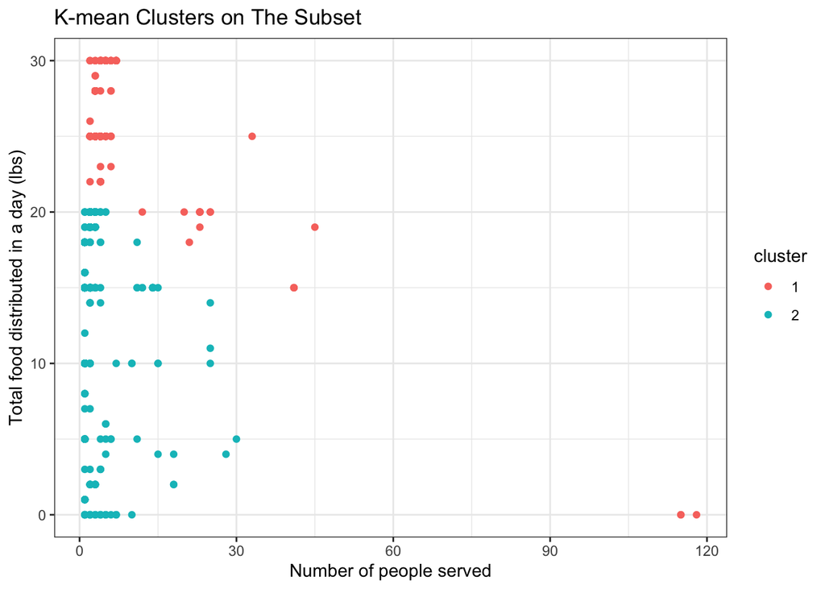

```r
clustered_subset <- clustered_data %>%
  filter(cluster == 1)

k_means_2 <- clustered_subset %>%
    select(Food.Pounds, Food.Provided.for) %>%
    kmeans(2)

clustered_data_2 <- clustered_subset %>%
  mutate(cluster = factor(k_means_2$cluster))

ggplot(clustered_data_2, aes(x = Food.Provided.for, y = Food.Pounds, col = cluster)) +
  geom_point() +
  labs(title = "K-mean Clusters on The Subset",
       x = "Number of people served",
       y = "Total food distributed in a day (lbs)") +
  theme_bw()
```

```r
clustered_data_summary_2 <- clustered_data_2 %>%
  mutate(avg_food_consumption = Food.Pounds/Food.Provided.for) %>%
  na.omit() %>%
  group_by(cluster) %>%
  summarise(cluster_mean_avg_food_consumption = mean(avg_food_consumption),
            n = sum(Food.Provided.for))

clustered_data_summary_2
```

```
## # A tibble: 2 x 3
##   cluster cluster_mean_avg_food_consumption     n
##   <fct>                               <dbl> <int>
## 1 1                                    7.67 39716
## 2 2                                   12.7  39353
```

This does seem to capture the bimodality shown above a little bit. If we do the single linear regression seperately on each sub cluster, we have

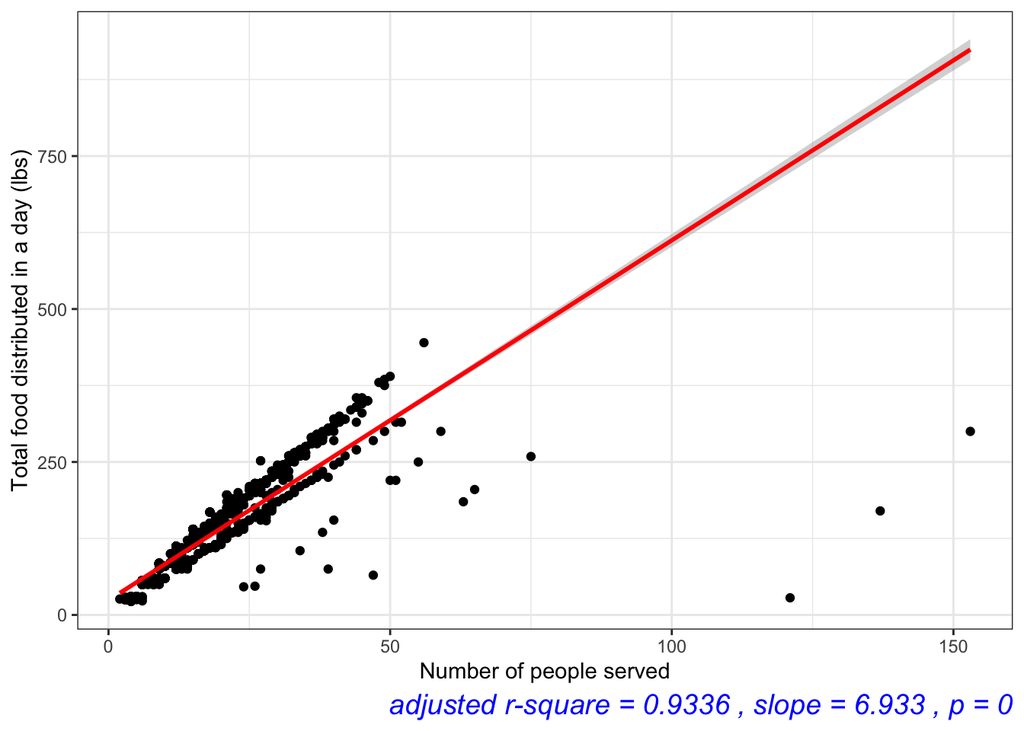

```r
group_1 <- clustered_data_2 %>%
  filter(cluster == 1)

group_1_avg <- group_1 %>%
  group_by(Date) %>%
  summarise(total_food_provided = sum(Food.Pounds),
            total_person_count = sum(Food.Provided.for),
            avg_food_consumed = sum(Food.Pounds)/sum(Food.Provided.for)) %>%
  arrange(desc(avg_food_consumed)) %>%
  na.omit()

group_2 <- clustered_data_2 %>%
  filter(cluster == 2)

group_2_avg <- group_2 %>%
  group_by(Date) %>%
  summarise(total_food_provided = sum(Food.Pounds),
            total_person_count = sum(Food.Provided.for),
            avg_food_consumed = sum(Food.Pounds)/sum(Food.Provided.for)) %>%
  arrange(desc(avg_food_consumed)) %>%
  na.omit()

fit_group_1 <- lm(total_food_provided ~ total_person_count - 1, data = group_1_avg)
p_1 <- ggplotRegression(fit_group_1) +
  labs(x = "Number of people served",
       y = "Total food distributed in a day (lbs)")

fit_group_2 <- lm(total_food_provided ~ total_person_count - 1, data = group_2_avg)
p_2 <- ggplotRegression(fit_group_2) +
  labs(x = "Number of people served",
       y = "Total food distributed in a day (lbs)")
p_1
```

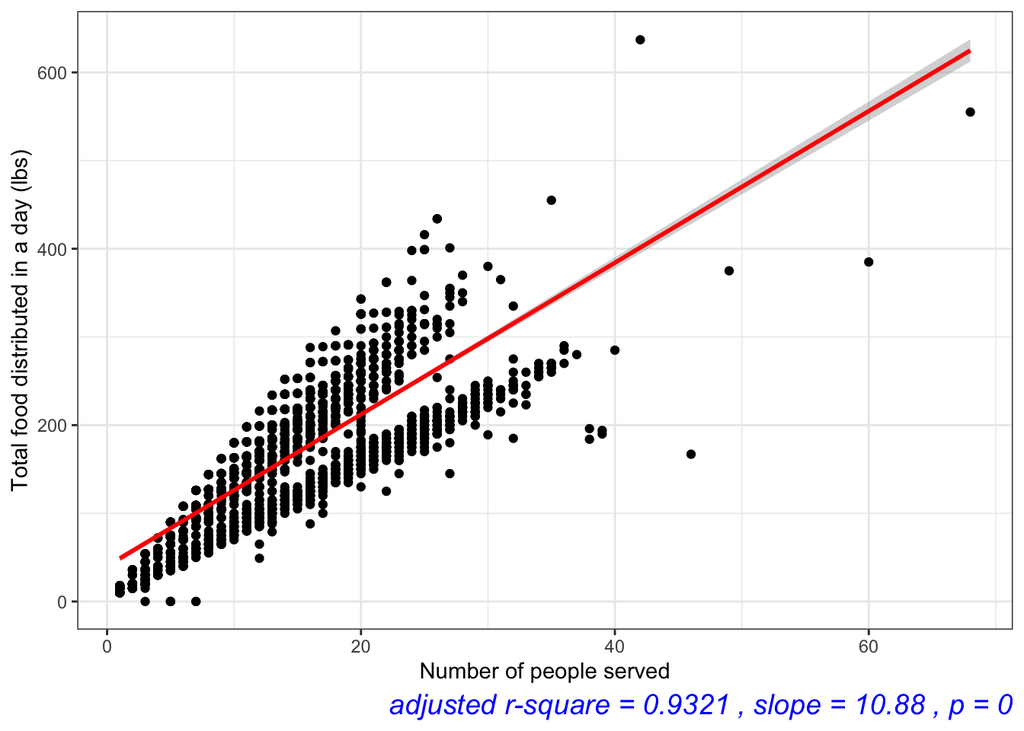

```r
p_2
```

From the plots above, we see that the estimated food consumed in pounds per person per day is 6.933 and 10.88 respectively for each sub cluster. The model fits the data well according to the $R^2_{adj}$ and $p$ values. The value of sub cluster 1 edges closer to the reported national average but is still above that.

Nevertheless, it is hard to tell whether we really separated the food served in the Cafe from that in the Pantry by using the k-mean clustering. It would be better if we can communicate more with UMD about the data entries to make sense of the clusters.

# Conclusions And Discussions

However, there are several cautions arise from the interpretations of this model. First, we do not have auxilliary data to show exactly the needs for food per date for people of different genders and ages and we also cannot ascertain the location the food was served. The bimodality of the average personal food consumption per day seems to suggest the above factors play a role in creating it.

We did explore further using the k-mean clustering method to subset data, and the method seems to group the data into two separate clusters with different regression means. Nevertheless, it is unable to know what was behind the division of the clusters with the available information. But if the UMD staff can recognize the difference, the separated regression means could serve as suggestions for the food portions served.